# Lab 9

STA 206 | Fall 2021

November 22, 2021

# Model Diagnostics: Outliers and Influential Cases

As you might have seen, there might be some extreme or unusual observations present in the data. *Gross errors* should be identified and dealt with during the data processing and exploratory data analysis steps. On the other hand, (more subtle) outliers are identified as part of *model diagnostics*. Outliers can pertain to the response Y and/or the X variables. First, we will look into detecting outliers for the response Y.

## Outlying Y observations

We are looking into the *realestate* data from the last week. Recall that the response variable is the residential home sales prices in a mid-western city; the potential predictors are some characteristics of the home and surrounding property. Six of these predictors are quantitative and five of them are categorical. We made a logarithm transformation on the response variable. We have also divided the data into training and validation sets.

```r
data <- read.table("realestate.txt", header = T)
Y <- data[, 2]
y <- log(Y)
# categorical predictor variables
X_c <- data[, c(6, 8, 10, 11, 13)]
colnames(X_c) <- c("AC", "pool", "quality", "style", "hw")
# quantitative predictor variables
X_q <- data[, c(3, 4, 5, 7, 9, 12)]
colnames(X_q) <- c("sqf", "bedrm", "bathrm", "garage", "year", "lotsz")

# transformed dataset
d <- cbind(y, X_q, X_c)
str(d)
```

```
## 'data.frame':    522 obs. of  12 variables:
##  $ y      : num  12.8 12.7 12.4 12.2 12.5 ...
##  $ sqf    : int  3032 2058 1780 1638 2196 1966 2216 1597 1622 1976 ...
##  $ bedrm  : int  4 4 4 4 4 4 3 2 3 3 ...
##  $ bathrm : int  4 2 3 2 3 3 2 1 2 3 ...
##  $ garage : int  2 2 2 2 2 5 2 1 2 1 ...
##  $ year   : int  1972 1976 1980 1963 1968 1972 1972 1955 1975 1918 ...
##  $ lotsz  : int  22221 22912 21345 17342 21786 18902 18639 22112 14321 32358 ...
##  $ AC     : int  1 1 1 1 1 1 1 1 1 0 ...
##  $ pool   : int  0 0 0 0 0 1 0 0 0 0 ...
##  $ quality: int  2 2 2 2 2 2 2 2 3 3 ...
##  $ style  : int  1 1 1 1 7 1 7 1 1 1 ...
##  $ hw     : int  0 0 0 0 0 0 0 0 0 0 ...
```

```r
# split data into two halves (training and validation)
set.seed(100)
n <- nrow(d)/2
n
```

```
## [1] 261
```

```r
ind <- sample(1:(2 * n), n, replace = FALSE)
train <- d[ind, ]  #training set
valid <- d[-ind, ]  #validation/test set
```

Now we fit a model using only the variables `sqf` and `garage`. Once we have fit the model, we’d like to check if there are any outliers. As discussed in class, some (but not necessarily all) outlying cases may have an unduly strong influence on the fitted regression function and thus need to be dealt with (e.g., excluded).

We first show how to find the *studentized deleted residuals*, which can be used to identify outlying Y cases. *Deleted residuals* are derived by deleting the observation in model fitting when calculating its fitted value:
$$d_i = Y_i - \hat{Y}_{i(i)}$$

We can get the deleted residuals by the formula:
$$d_i=\frac{e_i}{1-h_{ii}}$$

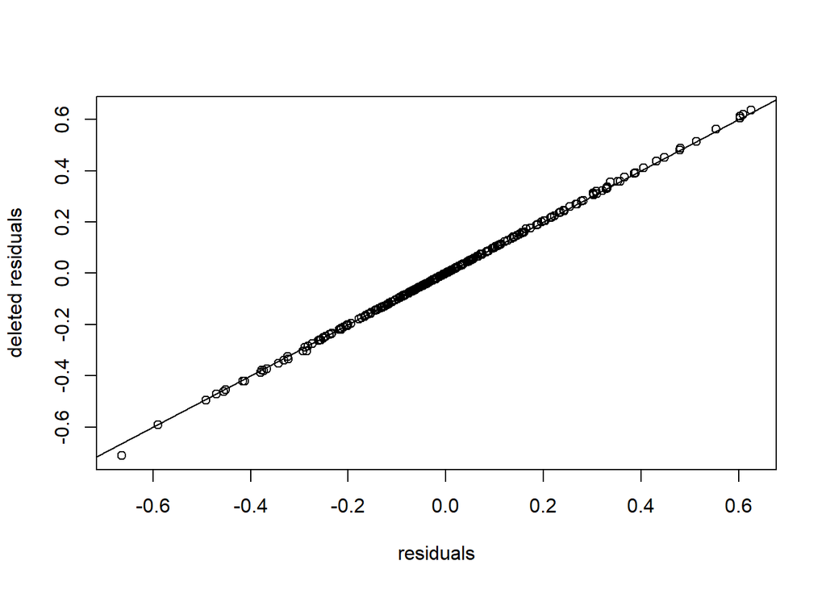

```r
fit <- lm(y ~ sqf + garage, data = train)
e <- fit$residuals  ##ordinary residuals
h <- influence(fit)$hat  ##diagonals of the hat matrix: a.k.a. leverage values
de <- e/(1 - h)  ##deleted residuals
plot(e, de, xlab = "residuals", ylab = "deleted residuals")
abline(0, 1)
```

```r
summary(h)
```

```
##     Min.  1st Qu.   Median     Mean  3rd Qu.     Max.
## 0.003833 0.005031 0.007940 0.011494 0.015387 0.067067
```

*Studentized deleted residuals* are the deleted residuals divided by their standard errors:

$$t_i = \frac{d_i}{s(d_i)}$$

In R, using the `MASS` package, we can find them using the function `studres`:

```r
# studentized deleted residuals
library(MASS)
stu.res.del <- studres(fit)
head(sort(abs(stu.res.del), decreasing = TRUE))
```

```
##      103      100       87       95      233       55
## 3.257237 2.977794 2.897405 2.867711 2.851894 2.784902
```

This code gives us the 6 largest studentized deleted residuals. We’d like to see whether these residuals exceed *Bonferroni’s threshold*, which at level $\alpha$ is $t(1-\frac{\alpha}{2n}; n-p-1)$. E.g.:

```r
qt(1-.1/(2*n), n-3-1) #Bonferroni's Threshold (alpha=0.1, n=sample size, p=3)
```

```
## [1] 3.599024
```

In this case, none of the cases is identified as outlying in Y according to the *Bonferroni’s procedure* at level $0.1$. Recall the Bonferroni’s procedure is conservative and thus lacks power. On the other hand, for data with moderate to large sample size (as is here), only extreme outliers are likely to have big influences, so a conservative procedure would usually be fine.

## Outlying X observations

Outlying X observations are identified through examining the diagonal elements $h_{ii}$ of the hat matrix, a.k.a., leverage. A large value of $h_{ii}$ indicates that the X values of the $i^{th}$ case is far away from the center of the X observations when taking into account the shape of the data.

In practice, $h_{ii} > \frac {2p}{n}$ is sometimes used as a criteria to identify the $i^{th}$ case as outlying with regard to its X values:

```r
h <- influence(fit)$hat
p <- 3
sort(h[which(h > 2 * p/n)], decreasing = TRUE)
```

```
##        103        129        254        511        464        506        210
## 0.06706695 0.05742340 0.05191373 0.05106524 0.05083025 0.05000896 0.03980772
##        154         71        146        130        395         72         82
## 0.03734415 0.03568136 0.03173689 0.03165834 0.03011558 0.02690588 0.02663354
##        125        128        219        291        171        191
## 0.02620867 0.02572644 0.02535459 0.02436347 0.02341468 0.02327577
```

This criteria detected 20 cases as outlying in X (with leverage greater than $2p/n=0.023$), although only a few cases have a leverage greater than $0.05$. Note that case 103 has the largest $|t_i|$ as well as the largest $h_{ii}$.

## Cook’s distance

*Cook’s distance* measures the aggregate influence of the $i^{th}$ case on all $n$ fitted values:
$$D_i := \frac{\sum_{j=1}^n (\hat{Y}_j-\hat{Y}_{j(i)})^2}{p \cdot MSE} = \frac {e_i^2}{p \cdot MSE}\frac{h_{ii}}{(1-h_{ii})^2} = \frac{r_i^2}{p}\frac{h_{ii}}{1-h_{ii}}$$

Here, $\hat{Y}_j$ is the fitted value for the $j^{th}$ case when all cases are used in fitting the model and $\hat{Y}_{j(i)}$ is the fitted value for the $j^{th}$ case when the $i^{th}$ case is excluded from the fitting. In practice, $D_i > \frac{4}{n-p}$ is sometimes used as a criteria for influential cases. A more conservative criteria is to require $D_i>1$ to be identified as an influential case.

It can also be thought of as defining the distance from $\hat{\beta}_{(i)}$ to $\hat{\beta}$.

$$D_i = \frac{(\hat{\beta}_{(i)}-\hat{\beta})^T(X^T X)(\hat{\beta}_{(i)}-\hat{\beta})}{p \cdot MSE}$$

The R code to calculate Cook’s distance is given below:

```r
res <- fit$residuals
mse <- anova(fit)["Residuals", 3]
cook.d <- res^2 * h/(p * mse * (1 - h)^2)
```

Once the Cook’s distances are calculated, we can find which cases have Cook’s distance exceeding the threshold:

```r
sort(cook.d[which(cook.d > 4/(n - p))], decreasing = TRUE)
```

```
##        103        254        100         87         95        129        102
## 0.24510579 0.04723996 0.04704853 0.04165680 0.04055810 0.03792875 0.03581255
##        154        493         72        210         98         37        130
## 0.02764764 0.02763523 0.02745143 0.02652228 0.02630280 0.02554475 0.02544050
##         71        125        276        219         12         93        361
## 0.02527594 0.02336572 0.02279684 0.02115465 0.02056762 0.02004629 0.01903158
##        165         53
## 0.01737319 0.01595194
```

Note that, case 103 has a much larger Cook’s distance than the rest of the cases. Moreover, none of the cases has Cook’s distance exceeding 1.

We can also look at the Cook’s distance plot:

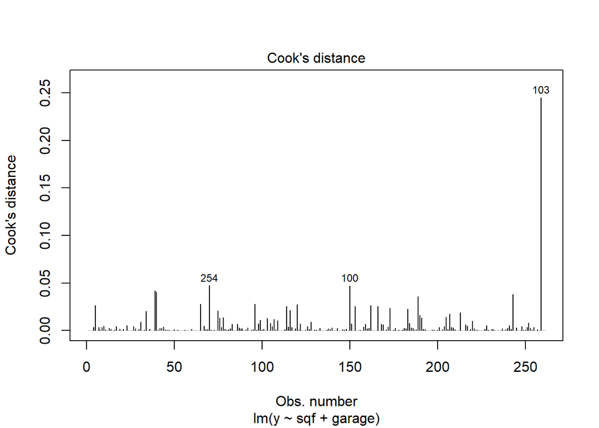

```r
plot(fit, which=4)
```

Moreover, we can check the Residuals vs. Leverage plot:

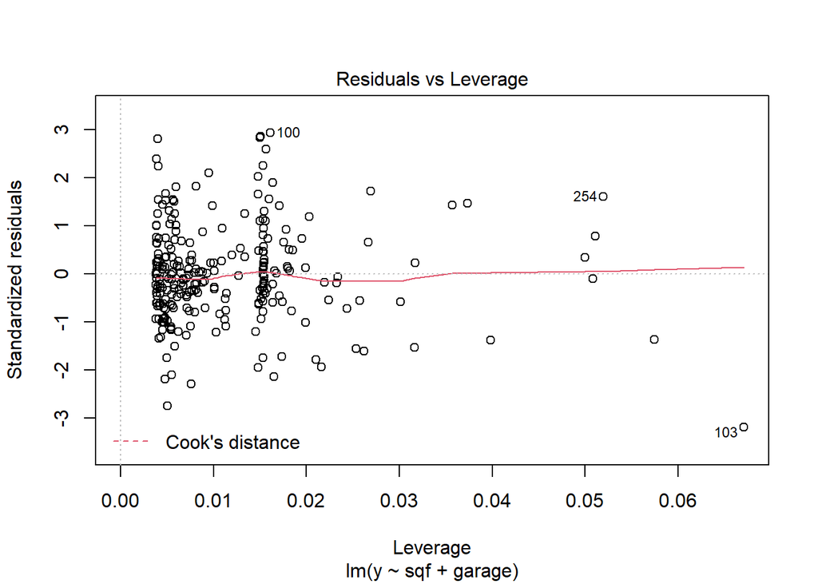

```r
plot(fit, which=5)
```

Here we have the *studentized residuals* plotted against the *leverage*. If for a case, both residual and leverage are large, i.e., the case tends to be outlying in both Y and X, then it could be an influential case which may require further investigation. In these two plots, potential influential cases have their *case labels* (rownames) shown next to them.

From these two plots, case 103 stands out as potentially influential. In the following, we will investigate its effects by fitting the model excluding case 103 and compare the results with those of the original fit. Be careful that, the *case labels* are the rownames, not the row indices. Here, case 103 does not correspond to the 103th row of the training data `train`; it actually corresponds to the 103th row of the orginal data `d`. The argument `subset` in the `lm` function allows us to specify a subset of observations to be used in the fitting process:

```r
which(rownames(train) == "103")  ##find row number of case 103 in training set
```

```
## [1] 259
```

```r
rbind(train[259, ], d[103, ])
```

```
##             y  sqf bedrm bathrm garage year lotsz AC pool quality style hw
## 103  13.07946 5032     7      3      3 1989 22000  1    0       1     7  0
## 1031 13.07946 5032     7      3      3 1989 22000  1    0       1     7  0
```

```r
fit.103 <- lm(y ~ sqf + garage, data = train, subset = setdiff(rownames(train), "103"))  ##exclude case 103
rbind(fit$coefficients, fit.103$coefficients)  ##compare fitted regression coefficients
```

```
##      (Intercept)          sqf    garage
## [1,]    11.13387 0.0004200971 0.1652098
## [2,]    11.10366 0.0004369818 0.1628682
```

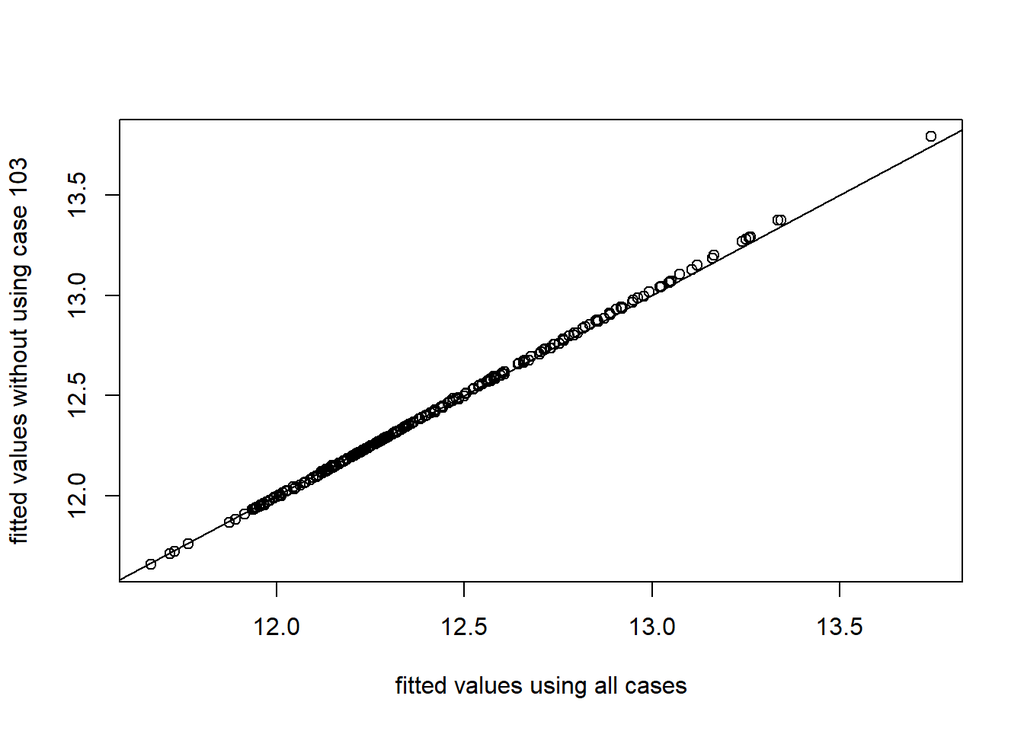

```r
plot(fit$fitted.value, predict(fit.103, train[, c("sqf", "garage")]), xlab = "fitted values using all cases",
    ylab = "fitted values without using case 103")  ## compare fitted values
abline(0, 1)
```

As can be seen, there is little difference in these two fits, so even the most influential case 103 can be retained.